# Product Categories & Review Date/Time Part 1

Eugenie

26/07/2019

# 1 Load Source File

Data pre-processing is included, where special chars and minimal stop-words are removed.

```r
## load review data
source("~/Dropbox/Eugenie/scripts/utils.R")
```

# 2 Data Processing

Add category data as extra columns. Join on either item_id or child_id.

```r
reviews2.temp <- reviews2.csv
```

# 3 Product Category vs. Rating

## 3.1 Check records with no category

To my surprise, 9.27% of the total reviews still don’t have a category.

```r
cat_sum <- reviews2.temp %>%
  group_by(product_cat) %>%
  summarise(product.count = n()) %>%
  mutate(product.pct = product.count/sum(product.count)*100)
cat_sum
```

```
## # A tibble: 4 x 3
##   product_cat       product.count product.pct
##   <fct>                     <int>       <dbl>
## 1 none                      24466        9.27
## 2 phone_batteries           88899       33.7
## 3 phone_cables              68637       26.0
## 4 screen_protectors         82014       31.1
```

```r
reviews2.temp <- reviews2.temp[as.numeric(as.character(reviews2.temp$year))>2013,]
```

Drop records after 2018-10-07 since it’s not a full week.

```r
reviews2.temp <- reviews2.temp[reviews2.temp$date < '2018-10-07',]
```

Drop records with no product category.

```r
reviews2.temp <- reviews2.temp[reviews2.temp$product_cat != 'none',]
```

## 3.2 Check incentivized reviews after it got banned

```r
cat_sum <- reviews2.temp %>%
  mutate(is_after = ifelse(date > '2016-10-03','after 2016-10-03','before 2016-10-03')) %>%
  group_by(incentivized,is_after) %>%
  summarise(review.count = n()) %>%
  mutate(review.pct = review.count/sum(review.count)*100)
cat_sum
```

```
## # A tibble: 4 x 4
## # Groups:   incentivized [2]
##   incentivized     is_after          review.count review.pct
##   <fct>            <chr>                    <int>      <dbl>
## 1 non-incentivized after 2016-10-03        178046      75.0
## 2 non-incentivized before 2016-10-03        59284      25.0
## 3 incentivized     after 2016-10-03            53       2.92
## 4 incentivized     before 2016-10-03         1763      97.1
```

# 4 Time Data vs. Rating

## 4.1 Data processing

Get selected columns for further analysis.

```r
reviews.product <- reviews2.temp[,c('recid','item_id','incentivized','product_cat','rating','word_count','helpful_yes','date','year','month','week')]
```

Split data on date without splitting incentivized vs. non-incentivized reviews after 2016-10-03.

```r
## split on date
reviews.product_non <- reviews.product[reviews.product$date<'2016-10-03'&reviews.product$incentivized=='non-incentivized',]
reviews.product_incentivized <- reviews.product[reviews.product$date<'2016-10-03'&reviews.product$incentivized=='incentivized',]
reviews.product_after <- reviews.product[reviews.product$date>'2016-10-03',]
```

Split data on date with split incentivized vs. non-incentivized reviews after 2016-10-03.

```r
## split on date
reviews.product_non1 <- reviews.product[reviews.product$date<'2016-10-03'&reviews.product$incentivized=='non-incentivized',]
reviews.product_incentivized1 <- reviews.product[reviews.product$date<'2016-10-03'&reviews.product$incentivized=='incentivized',]
reviews.product_non2 <- reviews.product[reviews.product$date>'2016-10-03'&reviews.product$incentivized=='non-incentivized',]
reviews.product_incentivized2 <- reviews.product[reviews.product$date>'2016-10-03'&reviews.product$incentivized=='incentivized',]
```

Compute rating stats without splitting incentivized vs. non-incentivized reviews after 2016-10-03.

```r
## mean rating by day
reviews.product_non <- reviews.product_non %>%
  group_by(product_cat, date) %>%
  mutate(day_rating = mean(rating))

reviews.product_incentivized <- reviews.product_incentivized %>%
  group_by(product_cat, date) %>%
  mutate(day_rating = mean(rating))

reviews.product_after <- reviews.product_after %>%
  group_by(product_cat, date) %>%
  mutate(day_rating = mean(rating))

## mean rating by week
reviews.product_non <- reviews.product_non %>%
  group_by(product_cat, year, week(date)) %>%
  mutate(week_rating = mean(rating))

reviews.product_incentivized <- reviews.product_incentivized %>%
  group_by(product_cat, year, week(date)) %>%
  mutate(week_rating = mean(rating))

reviews.product_after <- reviews.product_after %>%
  group_by(product_cat, year, week(date)) %>%
  mutate(week_rating = mean(rating))

## mean rating by month
reviews.product_non <- reviews.product_non %>%
  group_by(product_cat, month) %>%
  mutate(month_rating = mean(rating))

reviews.product_incentivized <- reviews.product_incentivized %>%
  group_by(product_cat, month) %>%
  mutate(month_rating = mean(rating))

reviews.product_after <- reviews.product_after %>%
  group_by(product_cat, month) %>%
  mutate(month_rating = mean(rating))
```

Compute rating stats with split incentivized vs. non-incentivized reviews after 2016-10-03, using the same procedure as above.

## 4.2 Plot mean rating over time by product_cat without splitting incentivized vs. non-incentivized reviews after 2016-10-03

Although there’re still reviews labelled as incentivized after 2016-10-03, since I’m not sure how that happened (e.g., prediction from ReviewMeta), I’m leaving it unsplit. The split version of the same analysis is in the next section.

### 4.2.1 Rating average by day

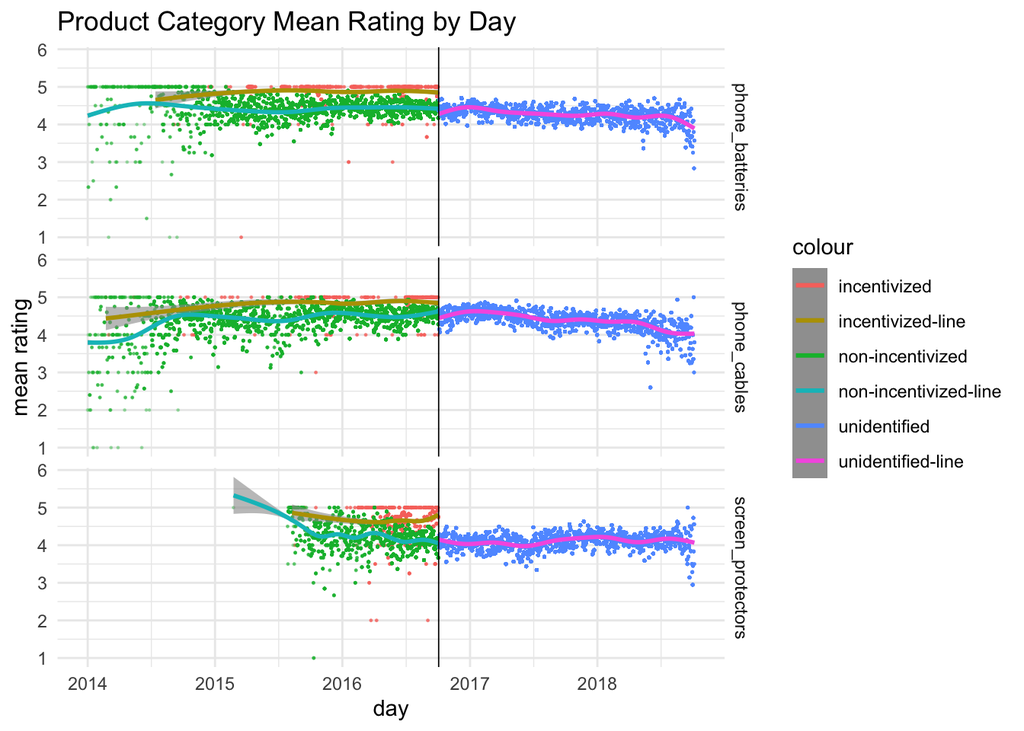

### 4.2.2 Rating averaged by week

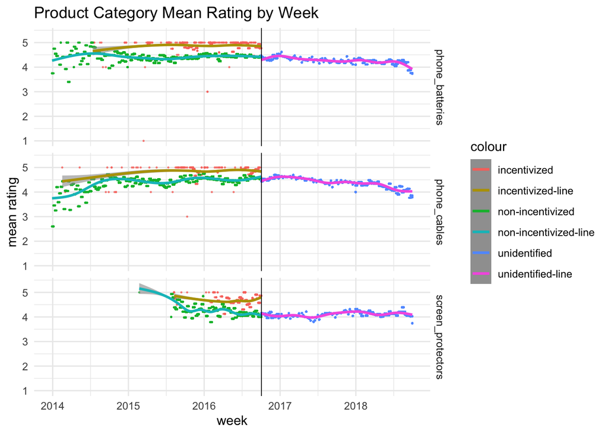

### 4.2.3 Rating averaged by month

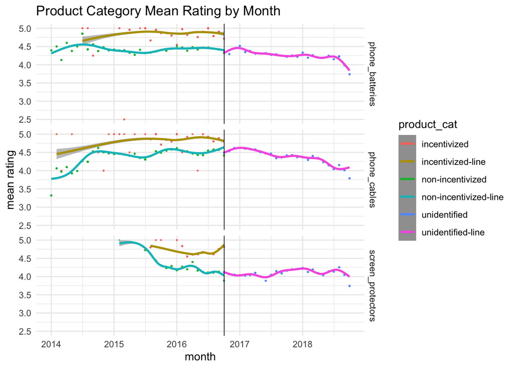

## 4.3 Plot mean rating over time by product_cat with split incentivized vs. non-incentivized reviews after 2016-10-03

### 4.3.1 Rating average by day

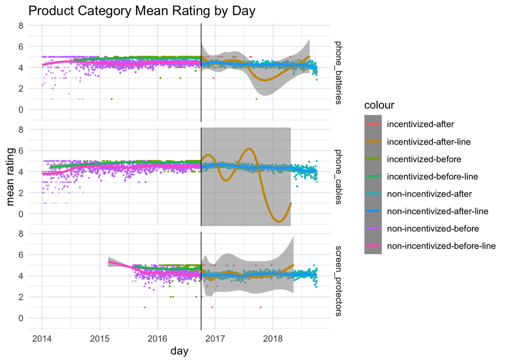

Noticed that due to the lack of data points (i.e., labelled incentivized reviews) after 2016-10-03, the lines are looking weird. I’m not sure if the result is meanful or not, so I’m dropping these for the analysis of word_count and helpful_yes.

Also, the distribution of the labelled incentivized reviews after 2016-10-03 is drastically different than the distribution of the incentivized review before 2016-10-03 for all three known product categories. How the ‘incentivized’ reviews got labelled is questionable.

### 4.3.2 Rating averaged by week

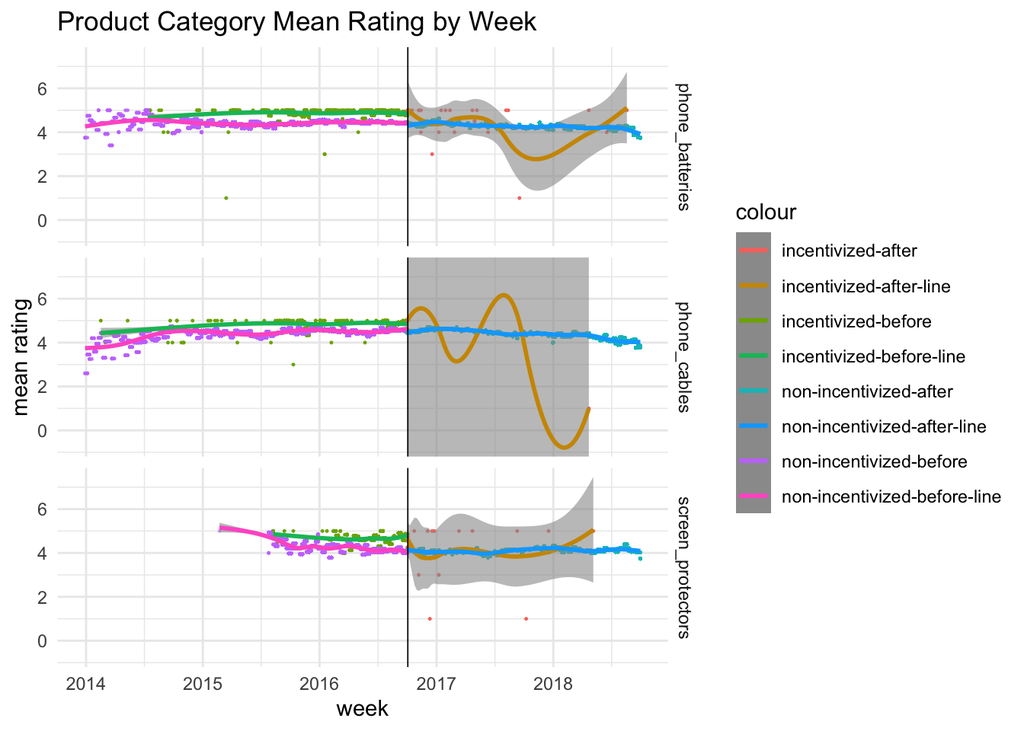

### 4.3.3 Rating averaged by month

Basically the same graph as the ‘rating average by week’.

# 5 Word Count

## 5.1 Data Processing

Compute word count stats with the same precudure as above.

## 5.2 Plot mean word_count over time by product_cat

### 5.2.1 word_count average by day

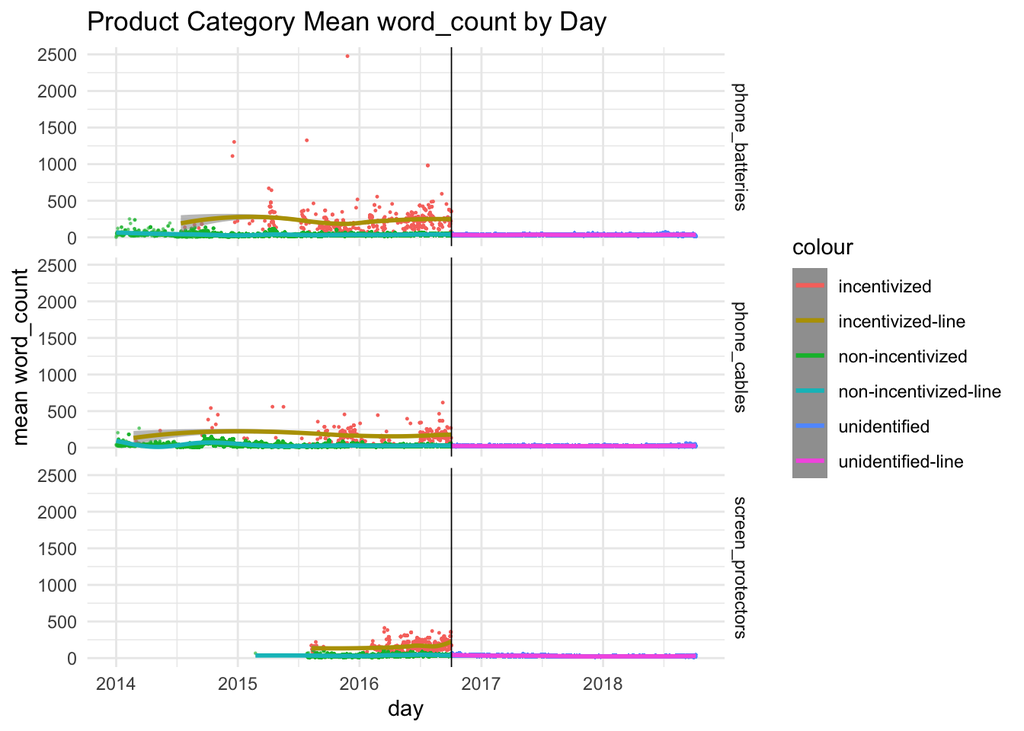

Same as the rating analysis, observed that prior to 2016-10-03, the daily word count average of incentivized reviews is higher and has a greater variation than non-incentivized reviews.

### 5.2.2 word_count averaged by week

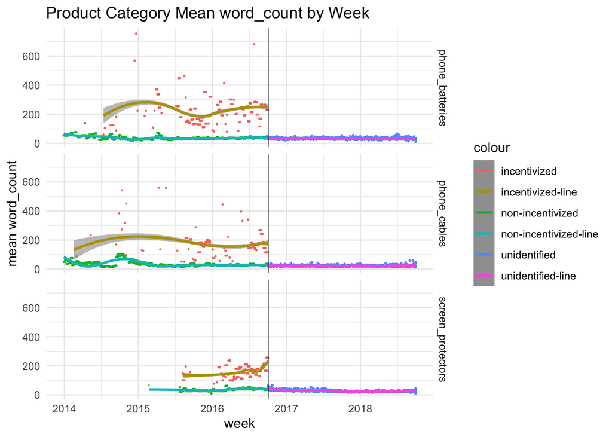

On a weekly scale, the average and variation of the word count of the incentivized reviews prior to 2016-10-03 is still high, but the range of the outliers got tuned down a bit.

### 5.2.3 word_count averaged by month

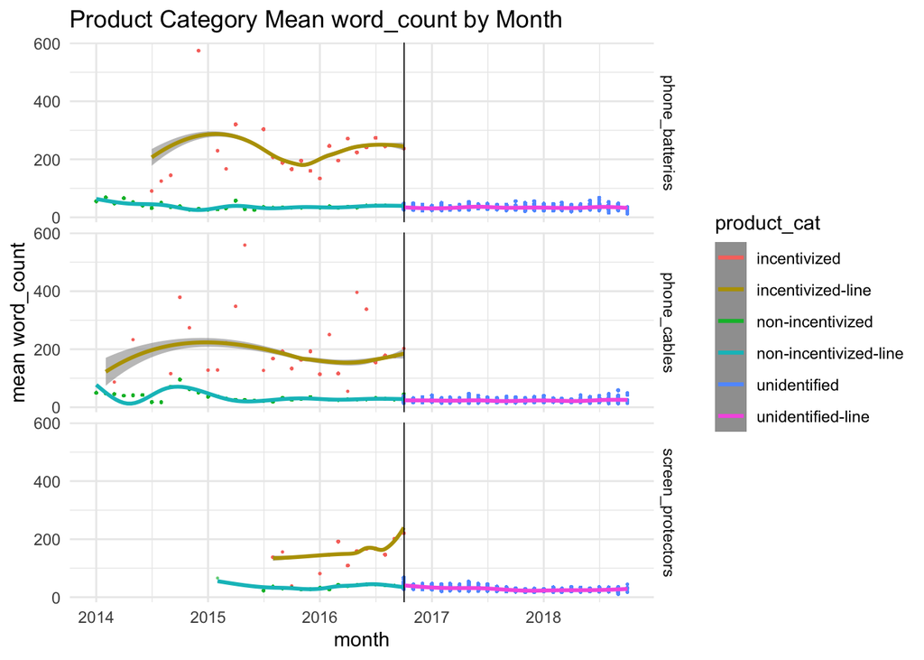

# 6 Helpful_yes

## 6.1 Data Processing

Compute helpful_yes stats with the same precudure as above.

## 6.2 General stats

As we discovered in previous analysis, the helpful_yes factor is very sparse. Also, it’s a bit suspicious that we only have 3 reviews with the count of helpful_yes greater than 0 since 2016-10-03.

```r
cat_sum <- reviews.product %>%
  mutate(is_after = ifelse(date > '2016-10-03','after 2016-10-03','before 2016-10-03')) %>%
  mutate(is_zero = ifelse(helpful_yes > 0,'greater than 0','0')) %>%
  group_by(is_after,is_zero) %>%
  summarise(review.count = n()) %>%
  mutate(review.pct = review.count/sum(review.count)*100)
cat_sum
```

```
## # A tibble: 4 x 4
## # Groups:   is_after [2]
##   is_after          is_zero        review.count review.pct
##   <chr>             <chr>                 <int>      <dbl>
## 1 after 2016-10-03  0                    178096  100.0
## 2 after 2016-10-03  greater than 0            3    0.00168
## 3 before 2016-10-03 0                     59856   98.0
## 4 before 2016-10-03 greater than 0         1191    1.95
```

## 6.3 Plot mean helpful_yes over time by product_cat

### 6.3.1 helpful_yes average by day

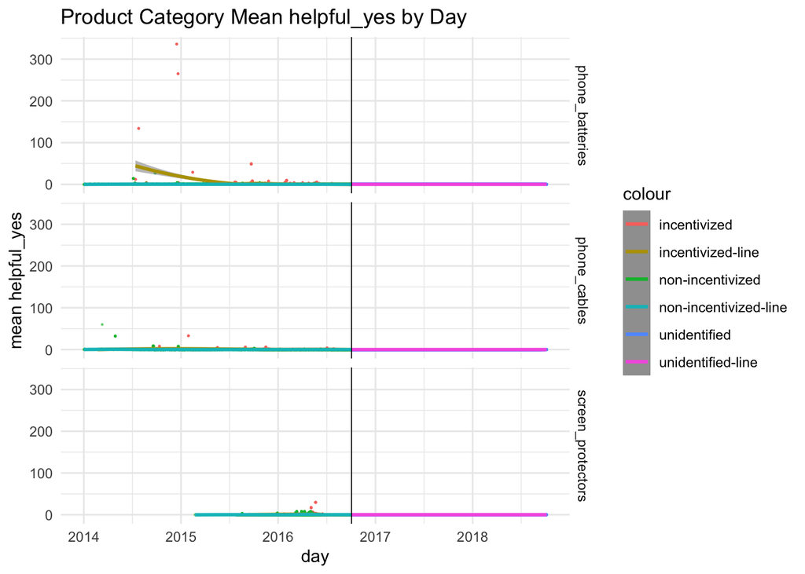

### 6.3.2 helpful_yes averaged by week

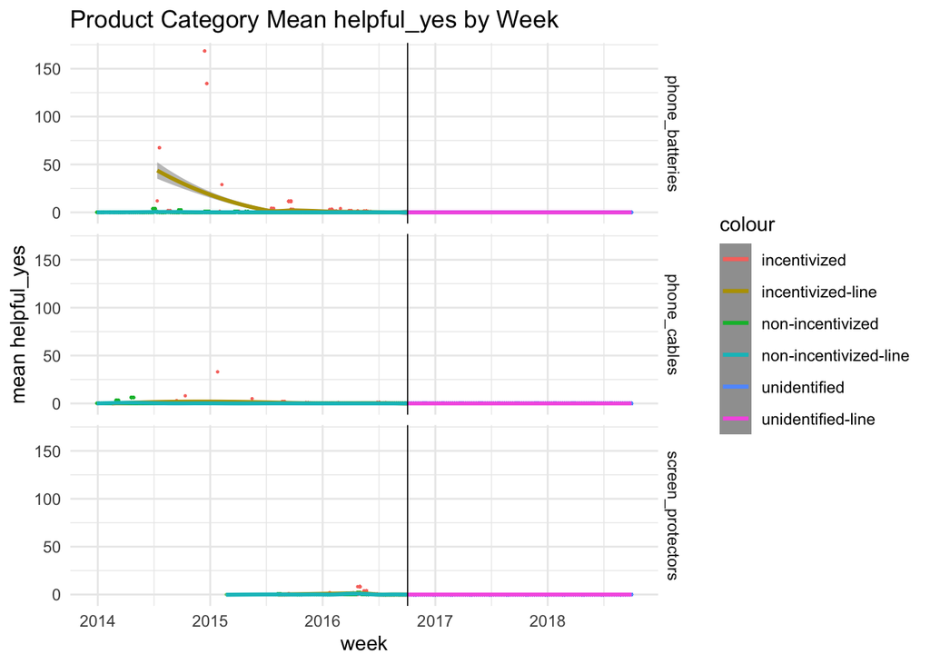

### 6.3.3 helpful_yes averaged by month

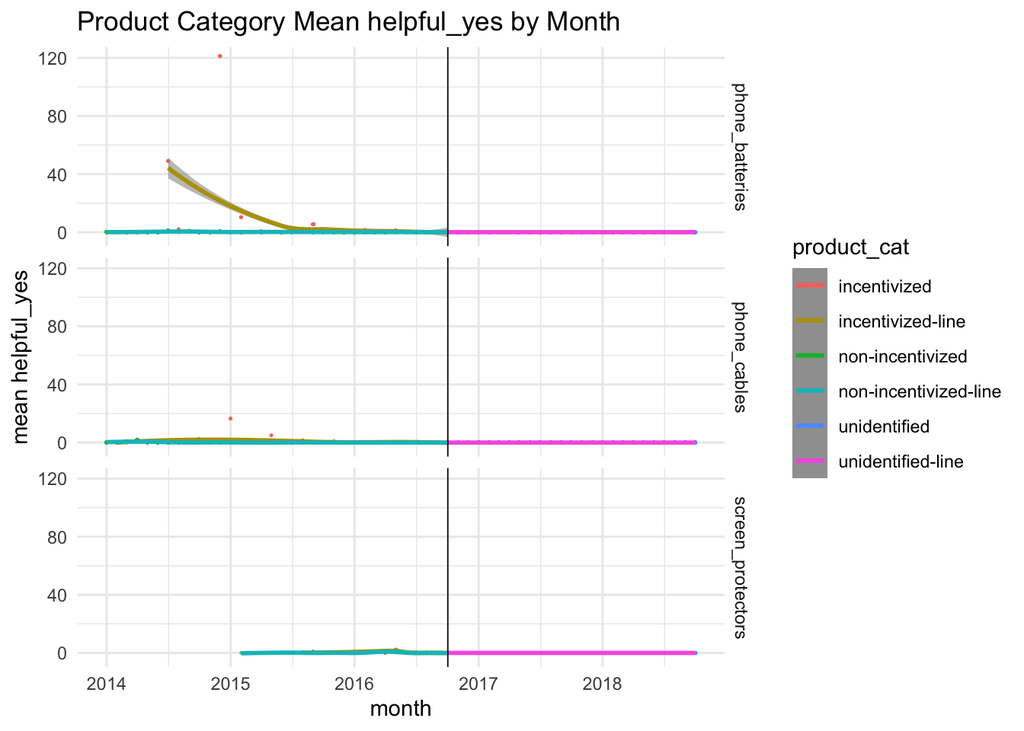